# L2 Proficiency as a Function of Age and Aptitiude (pa5)

Chris Oakden

4/3/2018

## Introduction

The purpose of this midterm is to address the question: is L2 learning affected by learner age and general language learning aptitude? The current study presents the results of a language proficiency exam experiment aimed at exploring this question. Participants were split up into two age groups (older vs younger), and their iq and language learning motivation values were obtained. Results of statistical modeling indicate that both age and general language learning aptitude affect L2 language learning, with the latter effect being further modulated by age.

## Load the Dataset

Here we load the dataset and look at the first six rows.

```r
#load the tidyverse and the data
library(tidyverse)
library(ggfortify)
data <- read_csv("./data_raw/lang_data_raw.csv")
#print the first six rows
head(data, 6)
```

```
## # A tibble: 6 x 4
##   id                  iq motivation  prof
##   <chr>            <dbl>      <dbl> <dbl>
## 1 p01_male_older    97.0       1.47 0.670
## 2 p02_female_older  91.5       1.31 0.460
## 3 p03_male_older    97.2       1.48 0.550
## 4 p04_female_older  91.5       1.31 0.490
## 5 p05_male_older    96.0       1.44 0.590
## 6 p06_female_older  93.8       1.37 0.620
```

## Tidy the Data

In order to make the data tidy, we must use `tidyr::separate` to break up the “id” column into three separate columns for participant ID, sex, and age. This will allow us to use “age” as a factor in our models.

```r
lang_tidy <- data %>%
  separate(., id, into = c("subject", "sex", "age"), sep = "_")
```

## Create the Composite Variable

```r
#create new variable and standardized version using mutate()
tidy_2 <- lang_tidy %>%
  mutate(., composite_score = log(iq / 80) + log(motivation)) %>%
  mutate(., cas_stan = (composite_score - mean(composite_score))/ sd(composite_score))
```

## Descriptive Statistics

Let us look briefly at some of the mean and standard deviation values of interest. What we would like to see is if, in general, younger L2 learners perform better on the proficiency test than older L2 learners, therefore we will group the data by age. The previous research does not suggest that biological sex plays a role in L2 learning, so we will not focus on that variable, in spite of it being specified in our data.

```r
#use summarize() to summarize the means/sd of proficiency score as a function of age
tidy_2 %>%
  group_by(., age) %>%
  summarize(., Score_Mean = mean(prof), Score_sd = sd(prof)) %>% knitr::kable(., format = 'html', digits = 2)
```

| age | Score_Mean | Score_sd |
| --- | --- | --- |
| older | 0.54 | 0.14 |
| younger | 0.67 | 0.13 |

The table above indicates that the younger learners’ mean proficiency score is higher than that of the older learners sampled in the study. Their standard deviations are roughly the same.

## Plot

One plot of the data is provided. This plot explores the possible relationship between the composite aptitude score and the score on the proficiency exam. The plot below (and the fitted regression line) suggests a positive correlation between the two variables, such that as the learners’ iq and motivation increase, so does their performances on the proficiency test.

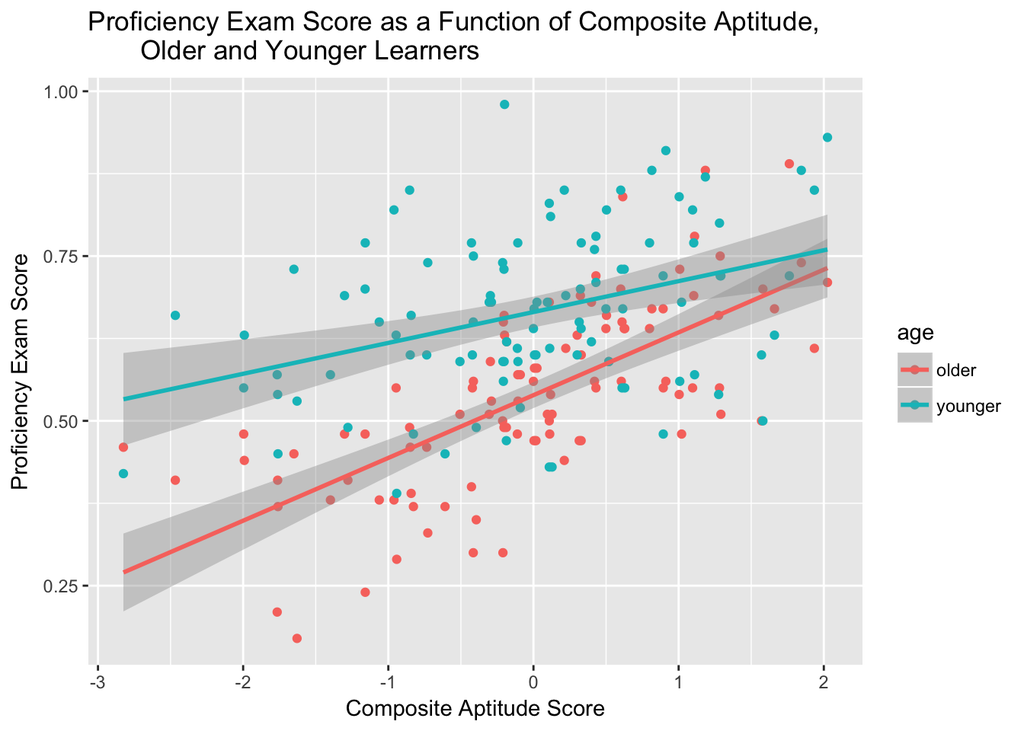

```r
#create a scatterplot using geom_point and a regression line using geom_smooth
#with the "lm" method specified
tidy_2 %>%
  ggplot(., aes(cas_stan, prof, color = age)) +
  geom_point() +
  geom_smooth(method = lm) +
  labs(x = "Composite Aptitude Score", y = "Proficiency Exam Score",
       title = "Proficiency Exam Score as a Function of Composite Aptitude,
       Older and Younger Learners")
```

The plotted values are also separated by the participants’ age, corroborating the generalization from the mean values, that is, that younger learners perform better on the proficiency exam than older learners. To test for main effects and interactions, it is necessary to fit models to these data.

## Model Fitting

The main research question here is to determine whether proficiency score varies as a function of age and composite score (and possibly via an interaction between the two). Below is a description of model fitting used to explore these questions.

The data were analyzed using a general linear model. Proficiency test score was the criterion with the categorical variable *learner age* (older/younger) and the continuous variable *composite score* (standardized via z-score transformation) as predictors. The age factor was dummy coded with older learners set as the reference group. See the models below.

```r
#fit models using lm()
mod_full <- lm(prof ~ age + cas_stan + age:cas_stan, data = tidy_2)
mod_int  <- lm(prof ~ age + cas_stan,                data = tidy_2)
mod_comp <- lm(prof ~ age,                           data = tidy_2)
mod_age  <- lm(prof ~ cas_stan,                      data = tidy_2)
mod_null <- lm(prof ~ 1,                             data = tidy_2)
```

Main effects and the age-by-composite-score interaction were assessed using nested model comparisons (using the `anova()` function. Experiment-wise alpha was set at 0.05.

```r
#compare models using the anova() function
#interaction term
comparison_1 <- anova(mod_int, mod_full)
#composite_score
comparison_2 <- anova(mod_comp, mod_int)
#age
comparison_3 <- anova(mod_age, mod_int)
```

# Results and Model Assumptions

A summary of the best-fitting model is provided below.

```r
summary(mod_full)
```

```
##
## Call:
## lm(formula = prof ~ age + cas_stan + age:cas_stan, data = tidy_2)
##
## Residuals:
##      Min       1Q   Median       3Q      Max
## -0.24110 -0.06781  0.00171  0.07496  0.32423
##
## Coefficients:
##                     Estimate Std. Error t value Pr(>|t|)
## (Intercept)          0.53900    0.01089  49.499  < 2e-16 ***
## ageyounger           0.12610    0.01540   8.189 3.33e-14 ***
## cas_stan             0.09521    0.01092   8.722 1.17e-15 ***
## ageyounger:cas_stan -0.04837    0.01544  -3.133    0.002 **
## ---
## Signif. codes:  0 '***' 0.001 '**' 0.01 '*' 0.05 '.' 0.1 ' ' 1
##
## Residual standard error: 0.1089 on 196 degrees of freedom
## Multiple R-squared:  0.4518, Adjusted R-squared:  0.4434
## F-statistic: 53.85 on 3 and 196 DF,  p-value: < 2.2e-16
```

To determine the reliability of the models, certain model diagnostics were performed, including tests for the normal distribution and homoskedasticity of the residuals (using `ggfortify::autoplot()`). In general, the mean of the residuals is zero (via a test using `mean(mod_full)$residuals`).

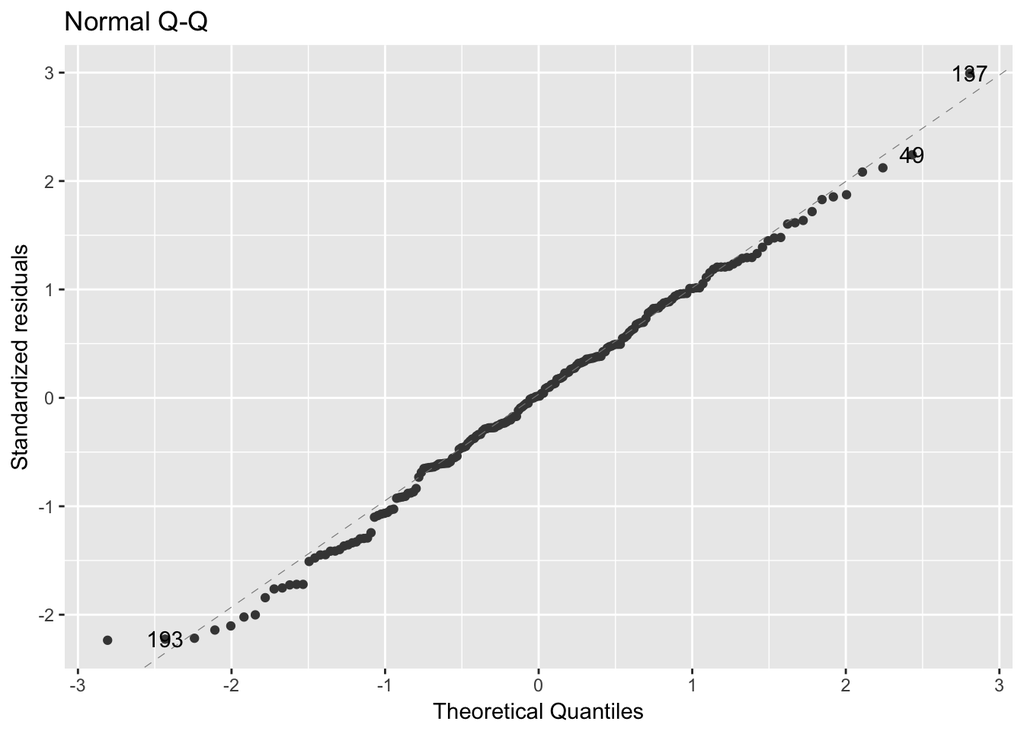

```r
#check the distribution of the residuals
autoplot(mod_full, which = 2)
```

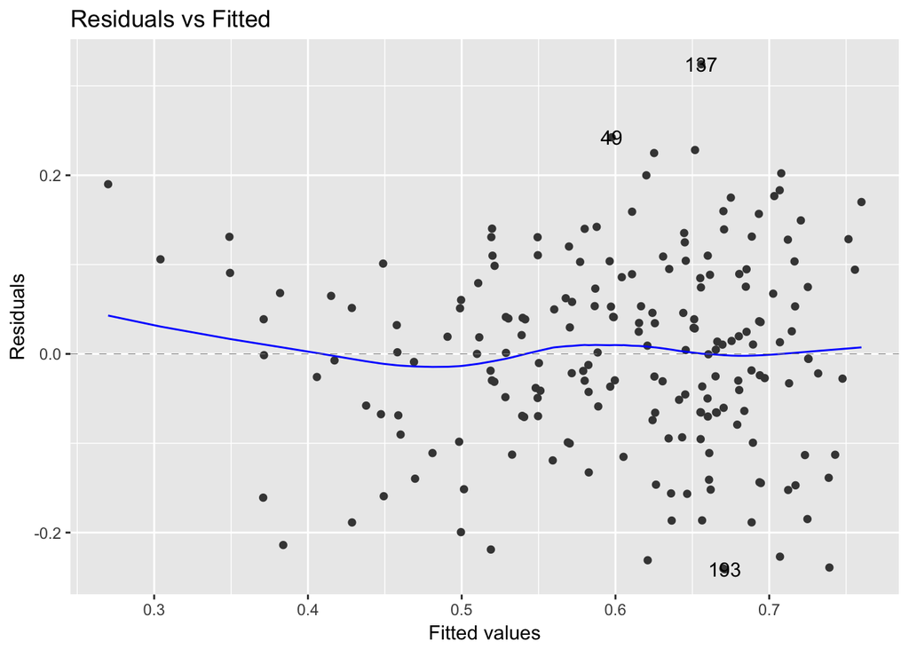

```r
#check whether the residuals are homoskedastic
autoplot(mod_full, which = 1)
```

Visual inspection of these plots indicates that these model assumptions have not been violated (modulo three influential data points). This model can therefore be considered reliable.

# Conclusion

This study has offered new data in the L2 learning literature, addressing the question of whether age and general language learning ability affect L2 learning. The results of a proficiency exam experiment indicate that age and general language learning ability to affect L2 learning, and further that the effect of general language learning ability is modulated by age.